# Laboratorio 1. Análisis Exploratorio. PCA, apriori

Juan De Leon, Maria Isabel Montoya

7/23/2021

## Análisis Exploratorio

Resumen del dataset:

```
##        Id           MSSubClass      MSZoning          LotFrontage
##  Min.   :   1.0   Min.   : 20.0   Length:1460        Min.   : 21.00
##  1st Qu.: 365.8   1st Qu.: 20.0   Class :character   1st Qu.: 59.00
##  Median : 730.5   Median : 50.0   Mode  :character   Median : 69.00
##  Mean   : 730.5   Mean   : 56.9                      Mean   : 70.05
##  3rd Qu.:1095.2   3rd Qu.: 70.0                      3rd Qu.: 80.00
##  Max.   :1460.0   Max.   :190.0                      Max.   :313.00
##                                                      NA's   :259
##     LotArea          Street             Alley             LotShape
##  Min.   :  1300   Length:1460        Length:1460        Length:1460
##  1st Qu.:  7554   Class :character   Class :character   Class :character
##  Median :  9478   Mode  :character   Mode  :character   Mode  :character
##  Mean   : 10517
##  3rd Qu.: 11602
##  Max.   :215245
##
##  LandContour         Utilities          LotConfig          LandSlope
##  Length:1460        Length:1460        Length:1460        Length:1460
##  Class :character   Class :character   Class :character   Class :character
##  Mode  :character   Mode  :character   Mode  :character   Mode  :character
##
##
##
##
##  Neighborhood        Condition1         Condition2          BldgType
##  Length:1460        Length:1460        Length:1460        Length:1460
##  Class :character   Class :character   Class :character   Class :character
##  Mode  :character   Mode  :character   Mode  :character   Mode  :character
##
##
##
##
##   HouseStyle         OverallQual      OverallCond      YearBuilt
##  Length:1460        Min.   : 1.000   Min.   :1.000   Min.   :1872
##  Class :character   1st Qu.: 5.000   1st Qu.:5.000   1st Qu.:1954
##  Mode  :character   Median : 6.000   Median :5.000   Median :1973
##                     Mean   : 6.099   Mean   :5.575   Mean   :1971
##                     3rd Qu.: 7.000   3rd Qu.:6.000   3rd Qu.:2000
##                     Max.   :10.000   Max.   :9.000   Max.   :2010
##
```

[output cut: 113 more lines]

```
##  Min.   : 1.000   Min.   :2006   Length:1460        Length:1460
##  1st Qu.: 5.000   1st Qu.:2007   Class :character   Class :character
##  Median : 6.000   Median :2008   Mode  :character   Mode  :character
##  Mean   : 6.322   Mean   :2008
##  3rd Qu.: 8.000   3rd Qu.:2009
##  Max.   :12.000   Max.   :2010
##
##    SalePrice
##  Min.   : 34900
##  1st Qu.:129975
##  Median :163000
##  Mean   :180921
##  3rd Qu.:214000
##  Max.   :755000
##
```

Tipo de cada variable del dataset:

```
##         Variable      Tipo.de.Variable
## 1             Id                   N/A
## 2     MSSubClass   Cualitativa Nominal
## 3       MSZoning   Cualitativa Nominal
## 4    LotFrontage Cuantitativa Discreta
## 5        LotArea Cuantitativa Discreta
## 6         Street   Cualitativa Nominal
## 7          Alley   Cualitativa Nominal
## 8       LotShape   Cualitativa Nominal
## 9    LandContour   Cualitativa Nominal
## 10     Utilities   Cualitativa Ordinal
## 11     LotConfig   Cualitativa Nominal
## 12     LandSlope   Cualitativa Nominal
## 13  Neighborhood   Cualitativa Nominal
## 14    Condition1   Cualitativa Nominal
```

[output cut: 67 more lines]

Graficos Exploratorios:

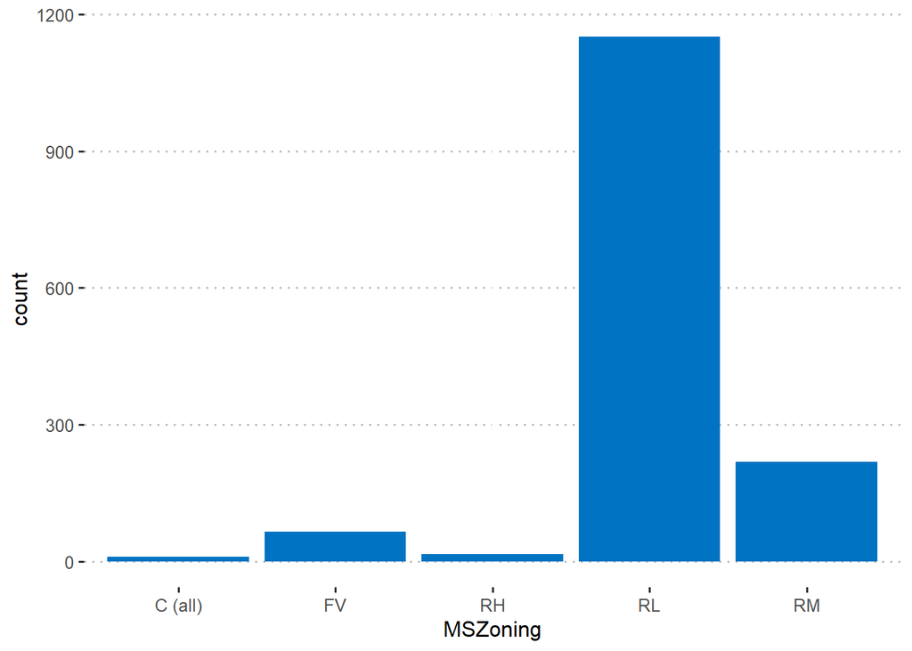

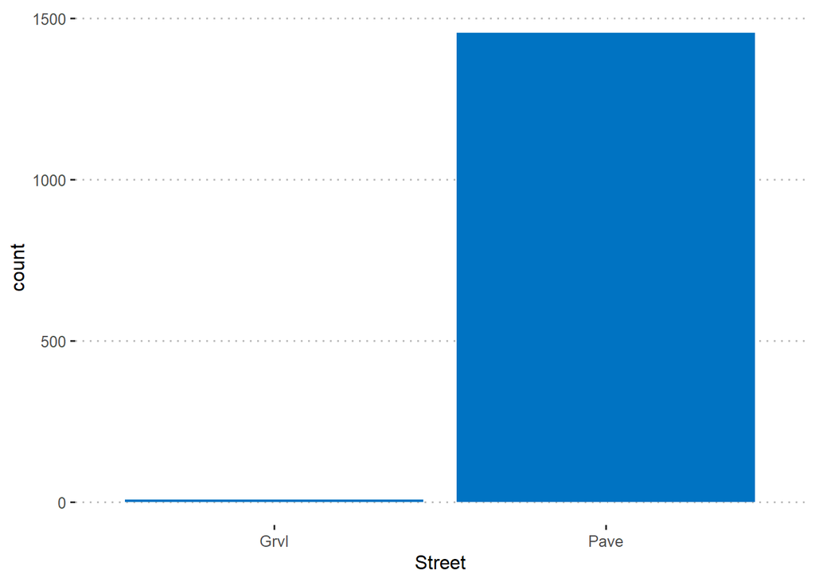

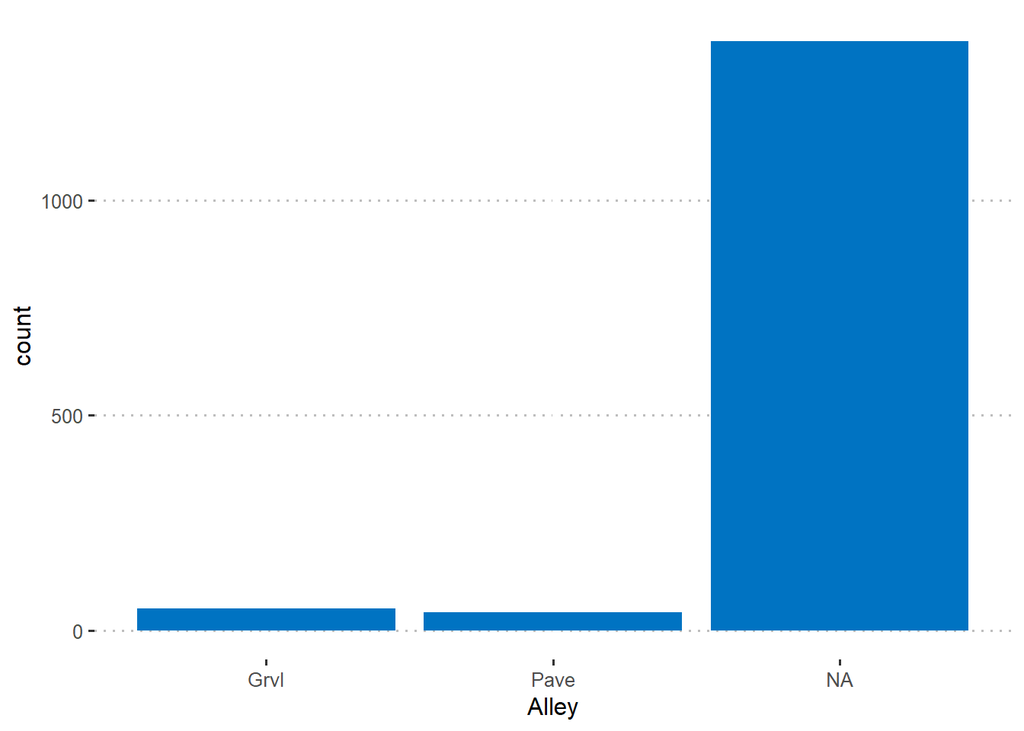

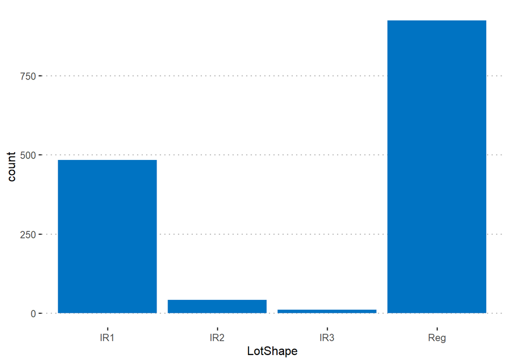

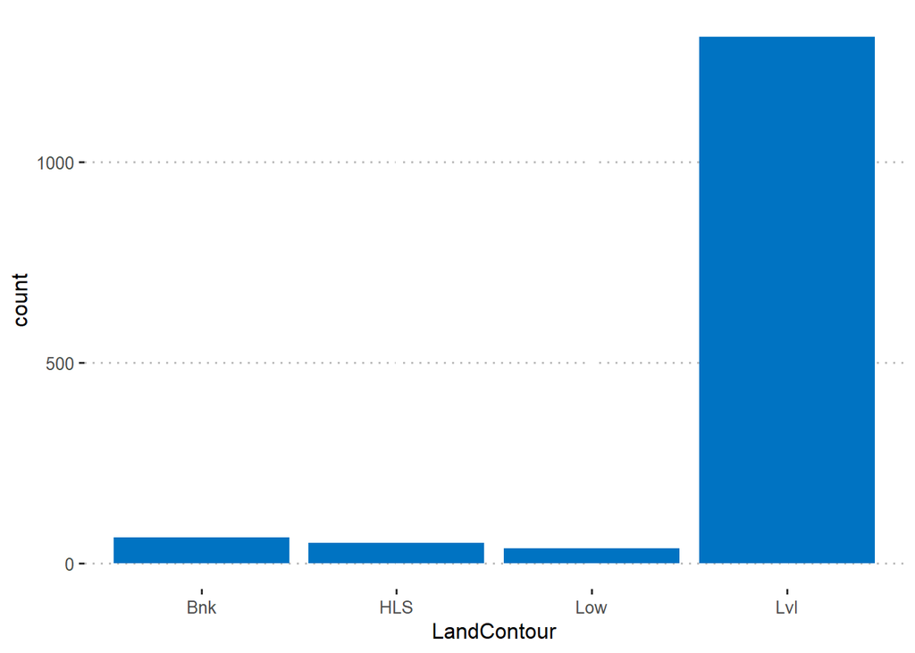

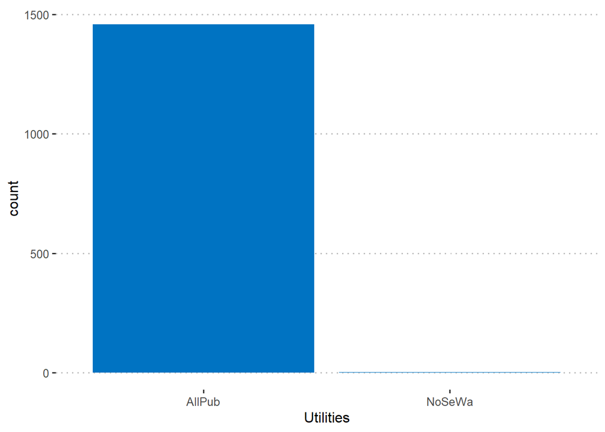

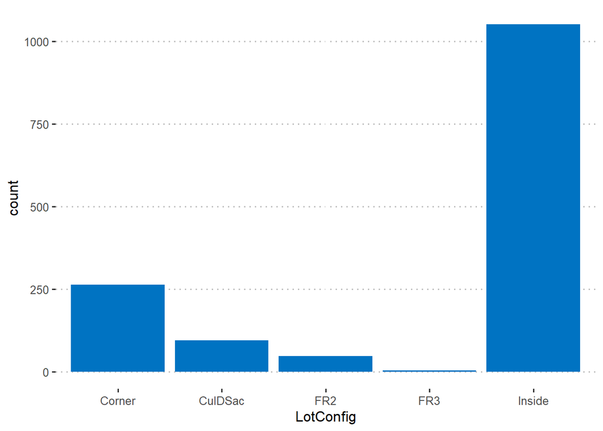

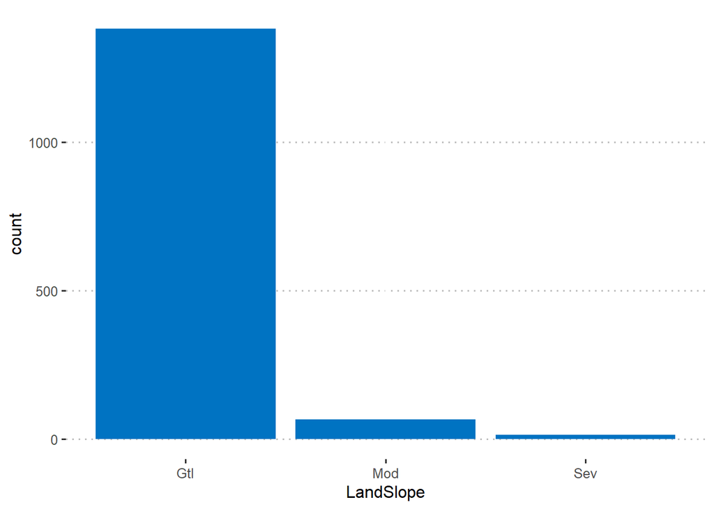

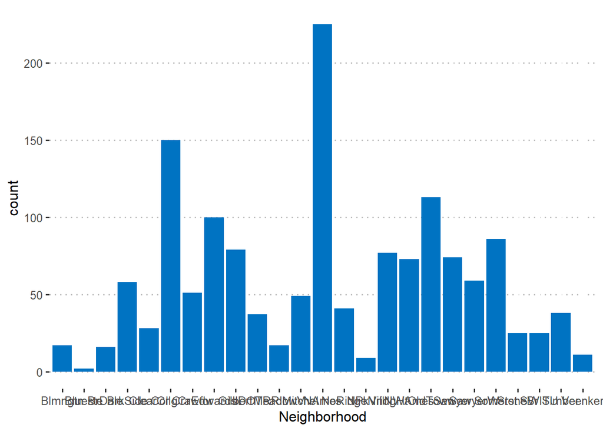

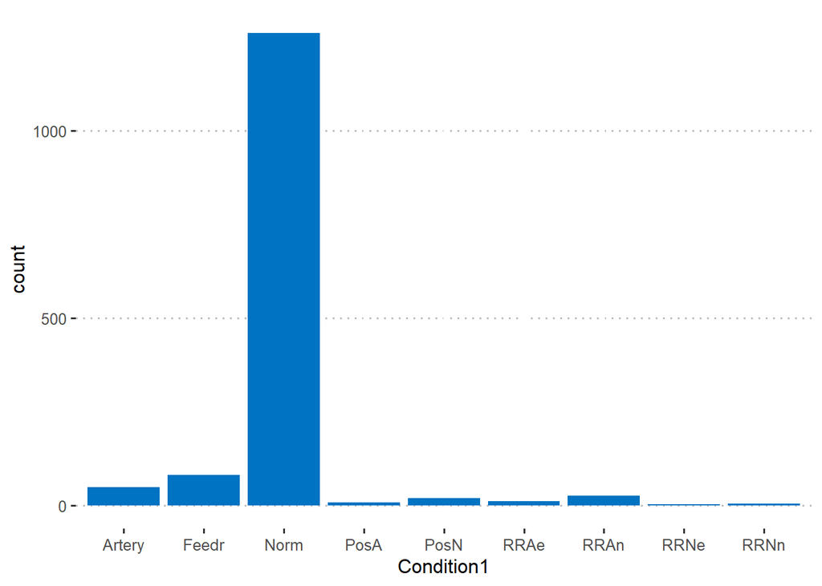

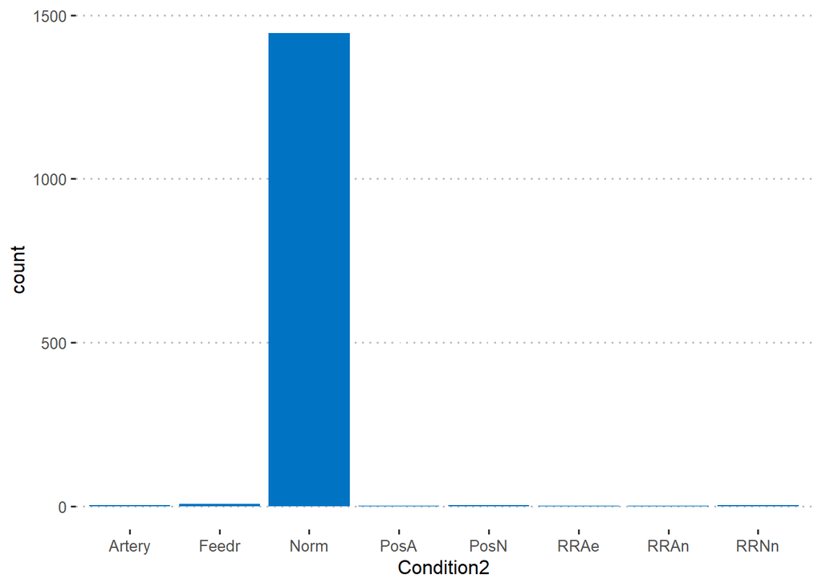

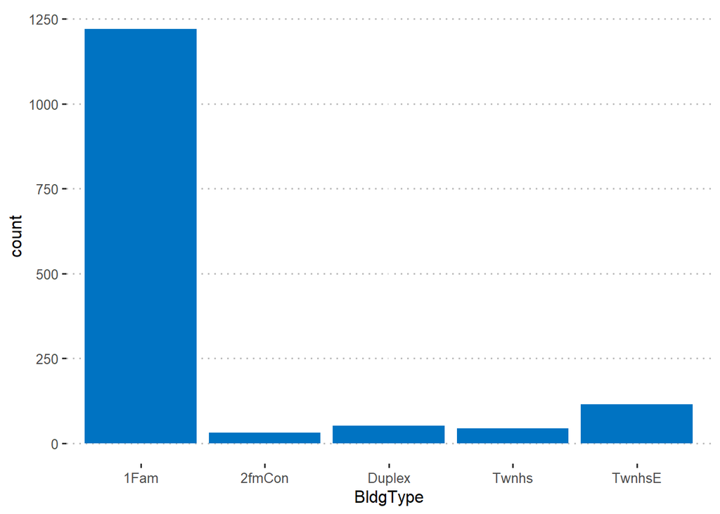

[34 more figures not shown]

En los histogramas anteriores podemos notar que en su mayoria, ninguna variable muestra normalidad. Todas tienen algun sesgo ya sea positivo o negativo.

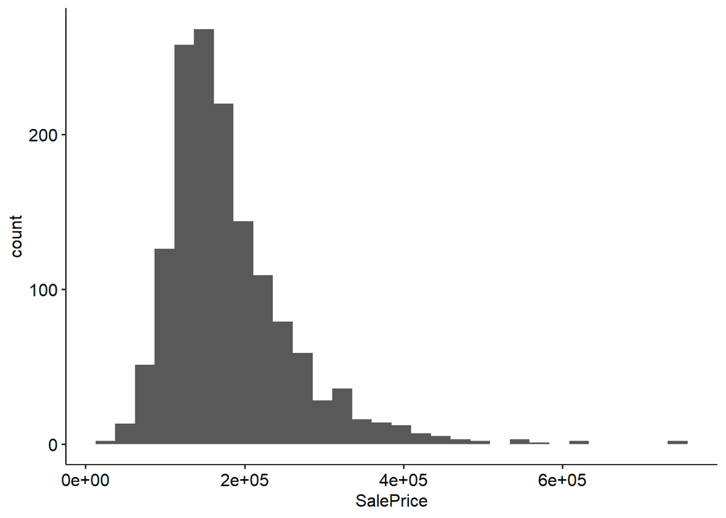

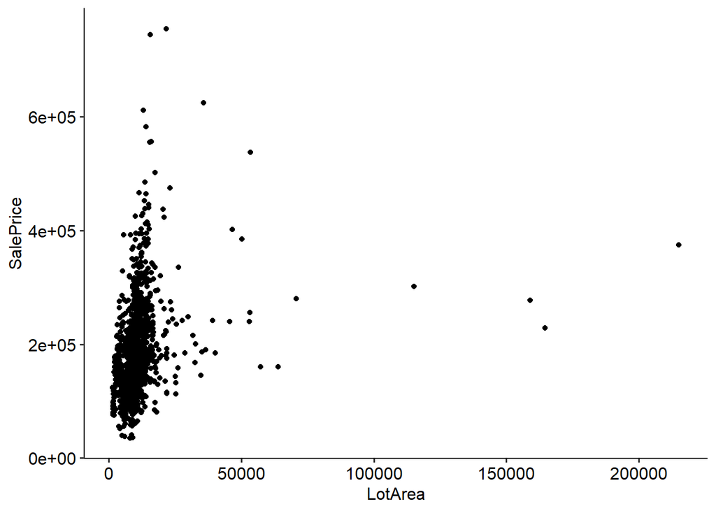

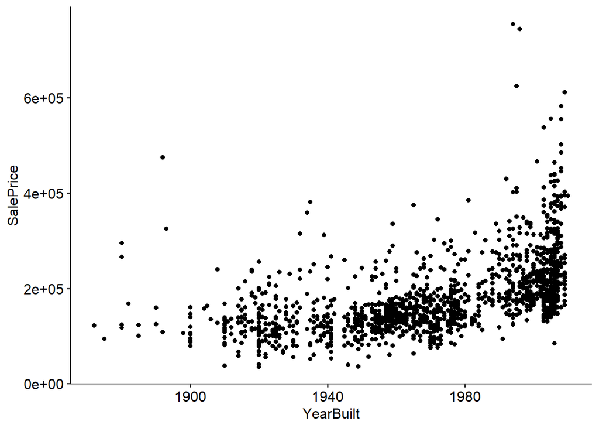

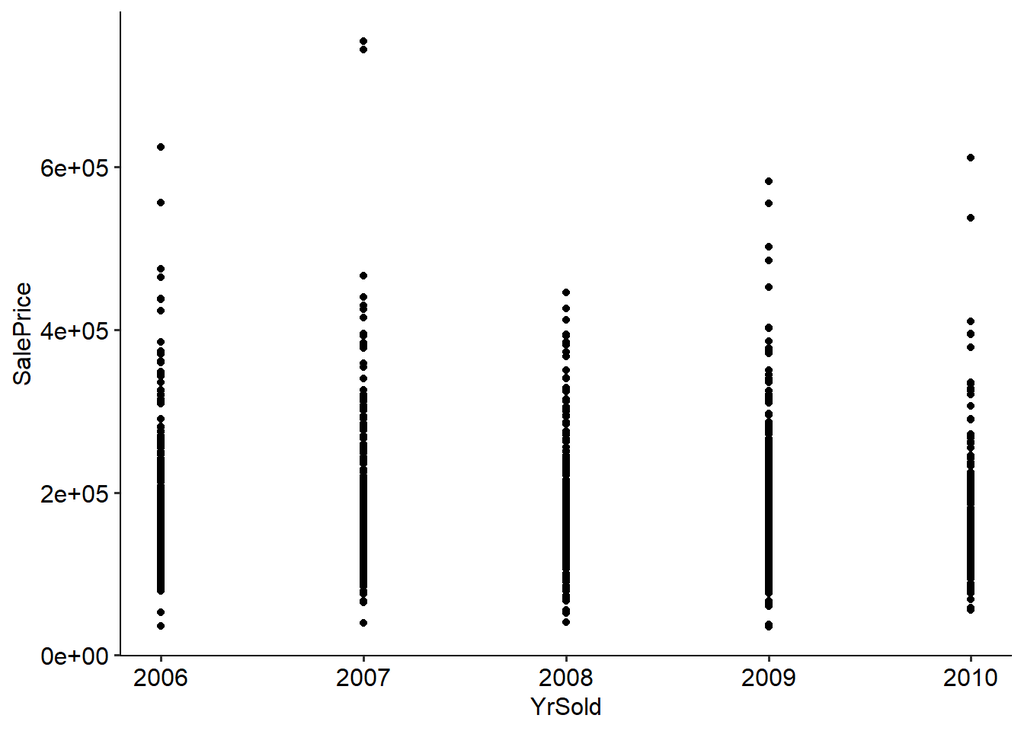

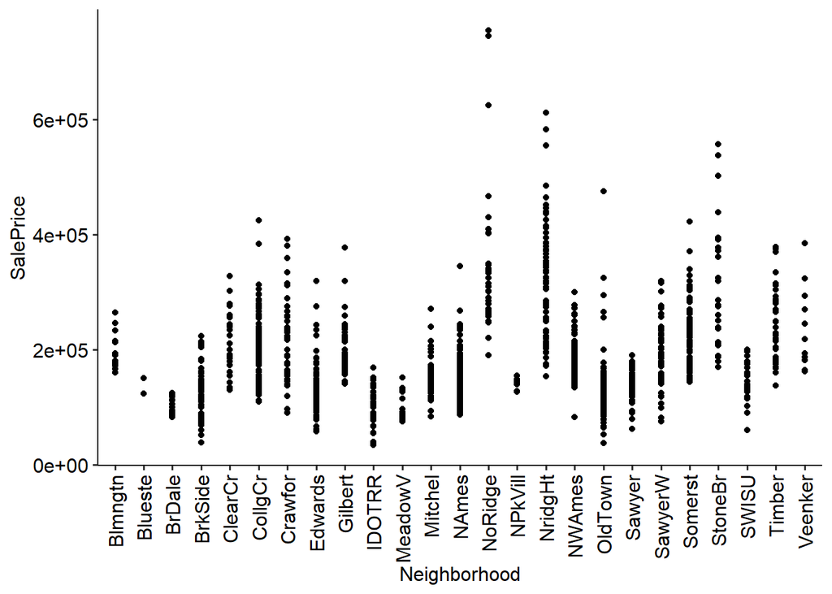

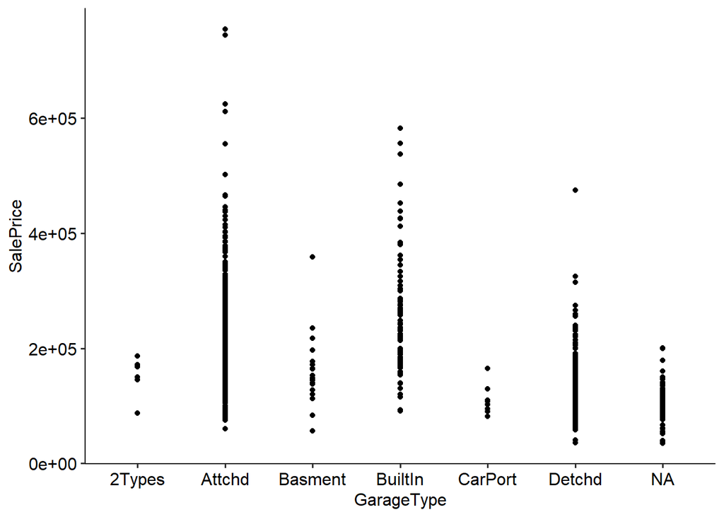

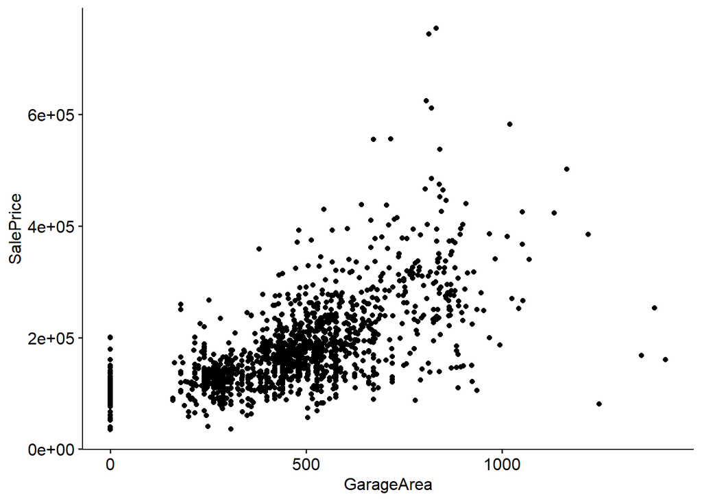

Un breve resumen:

| **Characteristic** | **N = 1,460**<sup>1</sup> |
| --- | --- |
| MSSubClass | 50 (20, 70) |
| MSZoning |  |
| C (all) | 10 (0.7%) |
| FV | 65 (4.5%) |
| RH | 16 (1.1%) |
| RL | 1,151 (79%) |
| RM | 218 (15%) |
| LotFrontage | 69 (59, 80) |
| Unknown | 259 |
| LotArea | 9,478 (7,554, 11,602) |
| Street |  |
| Grvl | 6 (0.4%) |
| Pave | 1,454 (100%) |
| Alley |  |
| Grvl | 50 (55%) |
| Pave | 41 (45%) |
| Unknown | 1,369 |
| LotShape |  |
| IR1 | 484 (33%) |
| IR2 | 41 (2.8%) |
| IR3 | 10 (0.7%) |
| Reg | 925 (63%) |
| LandContour |  |
| Bnk | 63 (4.3%) |
| HLS | 50 (3.4%) |
| Low | 36 (2.5%) |
| Lvl | 1,311 (90%) |
| Utilities |  |
| AllPub | 1,459 (100%) |
| NoSeWa | 1 (<0.1%) |

[output cut: 379 more lines]

Diagrama de correlación de las variables cuantitativas del dataset.

```
##    MSSubClass   LotFrontage       LotArea   OverallQual   OverallCond
##     "integer"     "integer"     "integer"     "integer"     "integer"
##     YearBuilt  YearRemodAdd    MasVnrArea    BsmtFinSF1    BsmtFinSF2
##     "integer"     "integer"     "integer"     "integer"     "integer"
##     BsmtUnfSF   TotalBsmtSF     X1stFlrSF     X2ndFlrSF  LowQualFinSF
##     "integer"     "integer"     "integer"     "integer"     "integer"
##     GrLivArea  BsmtFullBath  BsmtHalfBath      FullBath      HalfBath
##     "integer"     "integer"     "integer"     "integer"     "integer"
##  BedroomAbvGr  KitchenAbvGr  TotRmsAbvGrd    Fireplaces   GarageYrBlt
##     "integer"     "integer"     "integer"     "integer"     "integer"
##    GarageCars    GarageArea    WoodDeckSF   OpenPorchSF EnclosedPorch
##     "integer"     "integer"     "integer"     "integer"     "integer"
##    X3SsnPorch   ScreenPorch      PoolArea       MiscVal        MoSold
##     "integer"     "integer"     "integer"     "integer"     "integer"
##        YrSold    tipoDeCasa
##     "integer"     "numeric"
```

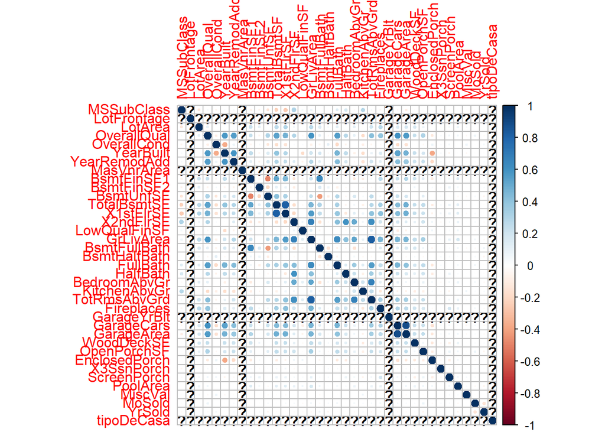

```
## [1] 2.054114e-16
```

El coeficiente de correlación entre todas las variables cuantitativas es 2.0541e-16 por lo que hay multicolinealidad entre ellas.

## Analisis de Componentes PCA

Estudie si es conveniente hacer un Análisis de Componentes Principales. Recuerde que puede usar el índice KMO y el test de esfericidad de Bartlett. Haga un análisis de componentes principales con las variables numéricas, discuta los resultados e interprete los componentes.

```
## [1] 0.76627
```

```
## [1] 18098
```

```
## $KMO
## [1] 0.76627
##
## $MSA
##                   MSA
## MSSubClass    0.54854
## LotFrontage   0.85390
## OverallCond   0.60265
## YearBuilt     0.78879
## YearRemodAdd  0.82598
## BsmtFinSF1    0.55078
## BsmtUnfSF     0.46221
## TotalBsmtSF   0.67311
## X1stFlrSF     0.82640
## LowQualFinSF  0.51791
## GrLivArea     0.78134
## BsmtFullBath  0.76933
## BsmtHalfBath  0.37786
## FullBath      0.84138
## HalfBath      0.51432
## BedroomAbvGr  0.76020
## KitchenAbvGr  0.51460
## TotRmsAbvGrd  0.83346
## Fireplaces    0.88045
## GarageYrBlt   0.86146
## GarageCars    0.85941
## GarageArea    0.83187
## WoodDeckSF    0.89789
## OpenPorchSF   0.91806
## EnclosedPorch 0.72513
## X3SsnPorch    0.44350
## ScreenPorch   0.57134
## PoolArea      0.65333
## MiscVal       0.53808
## MoSold        0.62402
## YrSold        0.45786
## tipoDeCasa    0.92851
##
## $Bartlett
## [1] 18098
```

[output cut: 91 more lines]

```
## GarageCars     0.16473692 -0.2302360  0.0946523  0.0503756  0.0461929
## GarageArea     0.21043571 -0.3305227  0.0013507  0.0413839  0.0372303
## WoodDeckSF     0.08202288  0.1462886 -0.0455360  0.1143014  0.0221560
## OpenPorchSF   -0.02683626 -0.0935465  0.0712724 -0.0241858 -0.0388290
## EnclosedPorch  0.06175635 -0.1061991 -0.1739633  0.1555084 -0.1444112
## X3SsnPorch     0.00075097  0.0236070 -0.0107047  0.0013050  0.0719198
## ScreenPorch   -0.05166949 -0.3331579  0.2214136 -0.3229917  0.0781625
## PoolArea      -0.07967655 -0.1988623 -0.5180829 -0.1601952  0.0787389
## MiscVal        0.05972466 -0.1309239 -0.0561503 -0.2853752 -0.0084850
## MoSold         0.02550236  0.0035909  0.1554289 -0.0058762  0.1207352
## YrSold         0.06127335  0.0681244 -0.0165986 -0.0529187 -0.1481198
## tipoDeCasa     0.02995035 -0.0337909  0.0886680  0.0533164 -0.0826088
##
## $RMS
## [1] 0.017908
```

De aqui podemos observar que tenemos un KMO de 0.76627 por lo que tiene una adecuación aceptable muestral. El coeficiente de Bartlett nos muestra que es de 18098, pero aun tenemos que hacer la prueba de Bartlett por lo que ponemos como hipótesis nula: H0: la matriz de correlaciones es igual a la matriz identidad Buscamos poder rechar Ho ya que significaría que hay suficiente multicolinealidad entre las variables.

```
## $chisq
## [1] 18098
##
## $p.value
## [1] 0
##
## $df
## [1] 496
```

el valor p es de 0 lo que lo hace menor a 0.05, esto nos dice que el análisis factorial si podrá funcionar. Se prosigue mostrando la matriz de correlacion

```
##               MSSubClass LotFrontage OverallCond  YearBuilt YearRemodAdd
## MSSubClass     1.0000000 -0.39268866  -0.0919287  0.0314053     0.010530
## LotFrontage   -0.3926887  1.00000000  -0.0427143  0.0995425     0.075219
## OverallCond   -0.0919287 -0.04271428   1.0000000 -0.4181206     0.047664
## YearBuilt      0.0314053  0.09954254  -0.4181206  1.0000000     0.618975
## YearRemodAdd   0.0105295  0.07521936   0.0476644  0.6189746     1.000000
## BsmtFinSF1    -0.0637718  0.23144424  -0.0414988  0.2186966     0.101554
## BsmtUnfSF     -0.1484224  0.10697839  -0.1529456  0.1780795     0.197627
## TotalBsmtSF   -0.2480472  0.37287142  -0.1862028  0.3944079     0.290714
## X1stFlrSF     -0.2532313  0.43978778  -0.1588236  0.2902979     0.261781
## LowQualFinSF   0.0206979  0.00329438   0.0095200 -0.1453014    -0.061924
## GrLivArea      0.0918910  0.38202104  -0.1147089  0.1874211     0.275017
## BsmtFullBath  -0.0111862  0.11500748  -0.0535820  0.1743391     0.104559
## BsmtHalfBath   0.0113349 -0.00105985   0.1218496 -0.0494699    -0.014926
## FullBath       0.1354334  0.16416782  -0.2287182  0.4968117     0.461714
## HalfBath       0.2064634  0.03194327  -0.0772017  0.2129760     0.153568
## BedroomAbvGr  -0.0416860  0.26735181   0.0021376 -0.0644824    -0.081409
## KitchenAbvGr   0.2660454 -0.00018185  -0.0945476 -0.1707866    -0.179803
## TotRmsAbvGrd   0.0526775  0.33810747  -0.0938193  0.0946580     0.153806
## Fireplaces    -0.0286039  0.24385155  -0.0198188  0.1201660     0.108816
## GarageYrBlt    0.0593110  0.05640792  -0.3414174  0.8239092     0.639238
## GarageCars    -0.0227271  0.27118995  -0.2674090  0.5256417     0.449370
## GarageArea    -0.0888175  0.35029619  -0.2255331  0.4636551     0.393240
## WoodDeckSF    -0.0193038  0.07156650  -0.0030874  0.2305260     0.240184
## OpenPorchSF    0.0063914  0.15495050  -0.0814110  0.2370344     0.253872
## EnclosedPorch -0.0190200  0.02055323   0.0614822 -0.3929804    -0.210481
## X3SsnPorch    -0.0401835  0.07287525  -0.0075654  0.0302287     0.028504
## ScreenPorch   -0.0227468  0.02836348   0.0741352 -0.0578222    -0.044929
## PoolArea       0.0020216  0.18693467  -0.0192664 -0.0019032     0.015834
## MiscVal       -0.0412290  0.00384129   0.1198270 -0.0958963    -0.038295
## MoSold        -0.0304860  0.02583396  -0.0156243  0.0199003     0.032850
## YrSold        -0.0111455  0.01544762   0.0454526 -0.0076187     0.042166
## tipoDeCasa    -0.0686069  0.29899971  -0.1432753  0.5836431     0.581438
##               BsmtFinSF1  BsmtUnfSF TotalBsmtSF  X1stFlrSF LowQualFinSF
## MSSubClass    -0.0637718 -0.1484224  -0.2480472 -0.2532313   0.02069789
## LotFrontage    0.2314442  0.1069784   0.3728714  0.4397878   0.00329438
## OverallCond   -0.0414988 -0.1529456  -0.1862028 -0.1588236   0.00951999
## YearBuilt      0.2186966  0.1780795   0.3944079  0.2902979  -0.14530137
## YearRemodAdd   0.1015540  0.1976273   0.2907141  0.2617811  -0.06192408
## BsmtFinSF1     1.0000000 -0.5107453   0.5089730  0.4414654  -0.04198414
```

[output cut: 176 more lines]

```
## TotRmsAbvGrd  -2.5366e-02  4.4433e-01
## Fireplaces    -3.0311e-02  4.3785e-01
## GarageYrBlt    1.0452e-02  5.3415e-01
## GarageCars    -3.0331e-02  6.1279e-01
## GarageArea    -1.4399e-02  5.6654e-01
## WoodDeckSF     1.6775e-02  2.8393e-01
## OpenPorchSF   -5.0478e-02  3.7398e-01
## EnclosedPorch -1.3748e-03 -1.5865e-01
## X3SsnPorch     2.0655e-02  3.4411e-02
## ScreenPorch   -5.6111e-03  9.8674e-02
## PoolArea      -5.1725e-02  4.0605e-02
## MiscVal        3.4095e-02 -2.3507e-02
## MoSold        -1.5269e-01  8.8291e-02
## YrSold         1.0000e+00  7.3426e-05
## tipoDeCasa     7.3426e-05  1.0000e+00
```

Por más que los valores pequeños son los más frecuentes, si podemos observar que hay variables altamente correlacionadas entre si. Como YearBuilt y YearRemodAdd. Se prosigue con la normalización de los datos.

```
## Standard deviations (1, .., p=32):
##  [1] 2.60537 1.63350 1.57435 1.37296 1.23133 1.11219 1.10018 1.06923 1.05428
## [10] 1.03111 1.00272 0.98275 0.96526 0.94168 0.91819 0.89120 0.86281 0.83845
## [19] 0.80365 0.75351 0.69308 0.64427 0.61548 0.55795 0.52514 0.45699 0.45004
## [28] 0.39829 0.38185 0.33528 0.28982 0.19223
##
## Rotation (n x k) = (32 x 32):
##                      PC1       PC2       PC3        PC4        PC5        PC6
## MSSubClass    -0.0291026 -0.027269  0.223717 -0.4376775  0.2250139 -0.1595612
## LotFrontage    0.1673147 -0.153359 -0.251405  0.1972011 -0.0094742  0.1515972
## OverallCond   -0.1127557 -0.082064 -0.140642 -0.0184330 -0.3872100  0.1634957
## YearBuilt      0.2596959  0.304534  0.195029 -0.0618131 -0.0074927 -0.0064497
## YearRemodAdd   0.2288867  0.206871  0.168340 -0.0420096 -0.2181268  0.1515472
## BsmtFinSF1     0.1348368  0.203123 -0.447456 -0.2329526  0.1318977 -0.0169297
## BsmtUnfSF      0.1275085 -0.131792  0.265277  0.4931248 -0.0676671 -0.0649429
## TotalBsmtSF    0.2692088  0.081277 -0.239680  0.2559367  0.0594430 -0.0731398
## X1stFlrSF      0.2680718 -0.019975 -0.259393  0.2512047  0.1305350 -0.0759879
## LowQualFinSF  -0.0167727 -0.116425 -0.040414 -0.0268830  0.0273916  0.2426419
## GrLivArea      0.2820882 -0.329103 -0.038001 -0.1381643 -0.0070180  0.0473790
## BsmtFullBath   0.0858248  0.233889 -0.367338 -0.2518749  0.1919894 -0.0045236
## BsmtHalfBath  -0.0286464 -0.018881 -0.054901 -0.0395961 -0.1551350  0.1355419
## FullBath       0.2663913 -0.103145  0.209032 -0.0366126  0.0707750 -0.0274555
## HalfBath       0.0945052 -0.122542  0.147256 -0.4111302 -0.2375271  0.0990761
## BedroomAbvGr   0.1006456 -0.441061  0.029712 -0.0788123  0.0173857  0.1114643
## KitchenAbvGr  -0.0126624 -0.214327  0.049546 -0.0613832  0.5401689 -0.2135684
## TotRmsAbvGrd   0.2225115 -0.411393  0.029306 -0.1231983  0.0689345  0.0558242
## Fireplaces     0.1670976 -0.128315 -0.196543 -0.0969842 -0.2217605 -0.1136259
## GarageYrBlt    0.2569693  0.276622  0.238994 -0.0432956  0.0192415  0.0539740
## GarageCars     0.2961393  0.044938  0.104650  0.0348477  0.1232279  0.0110066
## GarageArea     0.2913845  0.059262  0.012407  0.0754355  0.1350236  0.0305530
## WoodDeckSF     0.1388164  0.061330 -0.045499 -0.1200821 -0.0850251  0.2848288
## OpenPorchSF    0.1703154 -0.024437  0.018806 -0.0522687 -0.1640231 -0.2370017
## EnclosedPorch -0.0924197 -0.182039 -0.111612  0.0720233  0.0887490  0.2400155
## X3SsnPorch     0.0146043  0.023532 -0.013828  0.0719101 -0.0389200  0.0386823
## ScreenPorch    0.0195874 -0.072607 -0.132366 -0.0595714 -0.2812577 -0.4905316
## PoolArea       0.0444236 -0.073674 -0.205128 -0.0584138 -0.0097846  0.0463350
## MiscVal       -0.0148588 -0.072741 -0.109301 -0.0303627 -0.2024348 -0.2403222
## MoSold         0.0354752 -0.036887  0.025472  0.0162506 -0.0908953 -0.3684376
## YrSold        -0.0056096  0.031832 -0.018827 -0.0052544  0.0489599  0.2915126
## tipoDeCasa     0.3234844  0.024651  0.013942 -0.0579810 -0.1784464  0.0207226
```

[output cut: 150 more lines]

```
## TotRmsAbvGrd  -0.5064808 -0.1081337 -0.2181458  0.2827993  1.9850e-02
## Fireplaces    -0.0357991  0.0843824 -0.0012105  0.0064981  8.7599e-03
## GarageYrBlt    0.0795882  0.1041297  0.5093427  0.0743899  9.1686e-04
## GarageCars    -0.2345846 -0.5056469  0.3300868 -0.0609552  1.9795e-02
## GarageArea     0.2037996  0.4462978 -0.4690106  0.0623908 -4.7380e-03
## WoodDeckSF    -0.0269843  0.0072273 -0.0237859  0.0126496 -8.8847e-03
## OpenPorchSF   -0.0198390 -0.0739661 -0.0089505  0.0234823 -1.4179e-02
## EnclosedPorch -0.0317818 -0.0948722 -0.0640798  0.0076067 -9.3174e-03
## X3SsnPorch    -0.0120641  0.0023022 -0.0128741 -0.0007122  6.8197e-03
## ScreenPorch   -0.0382746 -0.0007533 -0.0158340 -0.0096093 -8.9153e-03
## PoolArea      -0.0051988 -0.0377314  0.0232438  0.0171821 -1.4004e-02
## MiscVal        0.0236865 -0.0194969 -0.0076553  0.0032431  1.7611e-03
## MoSold        -0.0099227 -0.0107835 -0.0059096  0.0091523  5.7691e-03
## YrSold        -0.0230965 -0.0208843 -0.0076897  0.0020788 -4.7568e-03
## tipoDeCasa     0.0758108  0.1632468  0.0940477  0.0645622 -1.8076e-02
```

```
## Importance of components:
##                          PC1    PC2    PC3    PC4    PC5    PC6    PC7    PC8
## Standard deviation     2.605 1.6335 1.5743 1.3730 1.2313 1.1122 1.1002 1.0692
## Proportion of Variance 0.212 0.0834 0.0775 0.0589 0.0474 0.0387 0.0378 0.0357
## Cumulative Proportion  0.212 0.2955 0.3730 0.4319 0.4793 0.5179 0.5557 0.5915
##                           PC9   PC10   PC11   PC12   PC13   PC14   PC15   PC16
## Standard deviation     1.0543 1.0311 1.0027 0.9827 0.9653 0.9417 0.9182 0.8912
## Proportion of Variance 0.0347 0.0332 0.0314 0.0302 0.0291 0.0277 0.0263 0.0248
## Cumulative Proportion  0.6262 0.6594 0.6908 0.7210 0.7501 0.7779 0.8042 0.8290
##                          PC17  PC18   PC19   PC20  PC21  PC22   PC23    PC24
## Standard deviation     0.8628 0.838 0.8037 0.7535 0.693 0.644 0.6155 0.55795
## Proportion of Variance 0.0233 0.022 0.0202 0.0177 0.015 0.013 0.0118 0.00973
## Cumulative Proportion  0.8523 0.874 0.8944 0.9122 0.927 0.940 0.9520 0.96172
##                           PC25    PC26    PC27    PC28    PC29    PC30    PC31
## Standard deviation     0.52514 0.45699 0.45004 0.39829 0.38185 0.33528 0.28982
## Proportion of Variance 0.00862 0.00653 0.00633 0.00496 0.00456 0.00351 0.00262
## Cumulative Proportion  0.97034 0.97686 0.98319 0.98815 0.99271 0.99622 0.99885
##                           PC32
## Standard deviation     0.19223
## Proportion of Variance 0.00115
## Cumulative Proportion  1.00000
```

De esto observamos los datos que se encuentran en los diferentes componentes (en este caso 32 porque se tiene 32 variables cuantitativas). Este summary del final nos demuestra que podemos tener representados el 80.42% de nuestros datos en solamente 15 componentes, en vez de tener las 32 variables.

Luego vamos a representar lo mismo solo que con un gráfico, donde nos muestra los vectores (en solamente dos dimensiones) y luego el summary de la representatividad que tiene los datos en los diferentes componentes. Otra vez, vemos que el 80.42% se representa en 15 componentes, por lo que si se puede reducir las dimensiones.

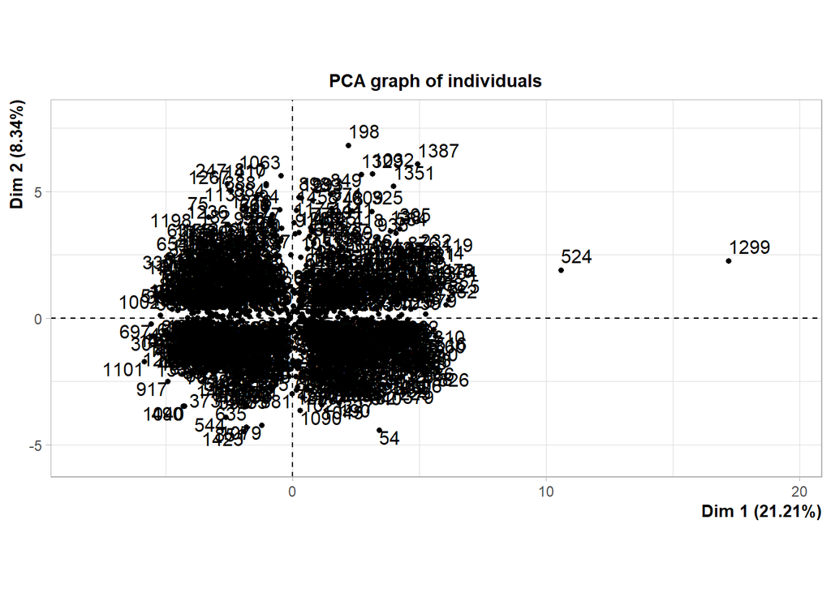

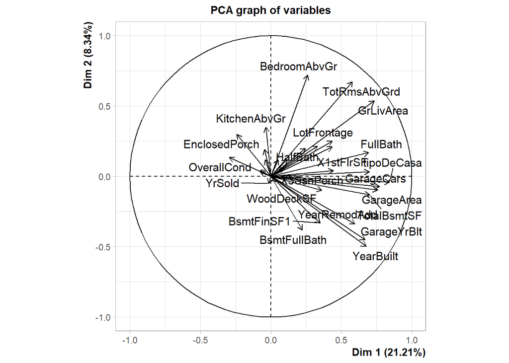

```
##
## Call:
## PCA(X = cuantitativas, scale.unit = T, ncp = ncol(cuantitativas))
##
##
## Eigenvalues
##                        Dim.1   Dim.2   Dim.3   Dim.4   Dim.5   Dim.6   Dim.7
## Variance               6.788   2.668   2.479   1.885   1.516   1.237   1.210
## % of var.             21.212   8.339   7.746   5.891   4.738   3.866   3.783
## Cumulative % of var.  21.212  29.551  37.296  43.187  47.925  51.791  55.573
##                        Dim.8   Dim.9  Dim.10  Dim.11  Dim.12  Dim.13  Dim.14
## Variance               1.143   1.112   1.063   1.005   0.966   0.932   0.887
## % of var.              3.573   3.473   3.322   3.142   3.018   2.912   2.771
## Cumulative % of var.  59.146  62.619  65.942  69.084  72.102  75.014  77.785
##                       Dim.15  Dim.16  Dim.17  Dim.18  Dim.19  Dim.20  Dim.21
## Variance               0.843   0.794   0.744   0.703   0.646   0.568   0.480
## % of var.              2.635   2.482   2.326   2.197   2.018   1.774   1.501
## Cumulative % of var.  80.419  82.901  85.228  87.424  89.443  91.217  92.718
##                       Dim.22  Dim.23  Dim.24  Dim.25  Dim.26  Dim.27  Dim.28
## Variance               0.415   0.379   0.311   0.276   0.209   0.203   0.159
## % of var.              1.297   1.184   0.973   0.862   0.653   0.633   0.496
## Cumulative % of var.  94.015  95.199  96.172  97.034  97.686  98.319  98.815
##                       Dim.29  Dim.30  Dim.31  Dim.32
## Variance               0.146   0.112   0.084   0.037
## % of var.              0.456   0.351   0.262   0.115
## Cumulative % of var.  99.271  99.622  99.885 100.000
##
## Individuals (the 10 first)
##                   Dist    Dim.1    ctr   cos2    Dim.2    ctr   cos2    Dim.3
## 1             |  4.069 |  1.476  0.029  0.132 | -0.823  0.023  0.041 | -0.796
## 2             |  5.672 |  0.086  0.000  0.000 | -0.238  0.002  0.002 |  1.545
## 3             |  3.462 |  1.704  0.039  0.242 | -0.794  0.021  0.053 | -0.738
## 4             |  6.040 | -0.956  0.012  0.025 |  1.060  0.038  0.031 |  0.621
## 5             |  5.314 |  4.146  0.230  0.609 |  0.743  0.019  0.020 | -0.335
## 6             | 12.193 | -0.893  0.011  0.005 | -2.648  0.239  0.047 |  0.791
## 7             |  4.656 |  3.405  0.155  0.535 | -1.561  0.083  0.112 |  1.740
## 9             |  7.249 | -1.559  0.033  0.046 |  3.395  0.393  0.219 |  0.107
## 10            |  7.877 | -3.407  0.155  0.187 |  0.387  0.005  0.002 |  1.657
## 11            |  4.219 | -2.466  0.081  0.342 | -1.324  0.060  0.099 |  1.720
##                  ctr   cos2
```

[output cut: 19 more lines]

```
## BsmtUnfSF     |  0.332  1.626  0.110 |  0.215  1.737  0.046 | -0.418  7.037
## TotalBsmtSF   |  0.701  7.247  0.492 | -0.133  0.661  0.018 |  0.377  5.745
## X1stFlrSF     |  0.698  7.186  0.488 |  0.033  0.040  0.001 |  0.408  6.728
## LowQualFinSF  | -0.044  0.028  0.002 |  0.190  1.355  0.036 |  0.064  0.163
##                 cos2
## MSSubClass     0.124 |
## LotFrontage    0.157 |
## OverallCond    0.049 |
## YearBuilt      0.094 |
## YearRemodAdd   0.070 |
## BsmtFinSF1     0.496 |
## BsmtUnfSF      0.174 |
## TotalBsmtSF    0.142 |
## X1stFlrSF      0.167 |
## LowQualFinSF   0.004 |
```

Procedemos a hacer gráficos que nos dice en cuantos componentes deberiamos de representar nuestro PCA.

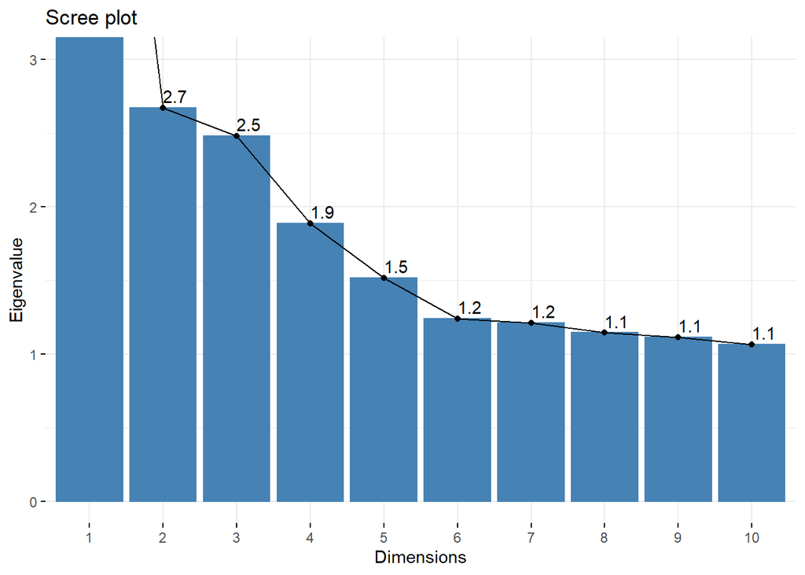

Proseguimos a ver cuales son las variables que mayor contribuyen a cada dimensión (las 15 mencionadas)

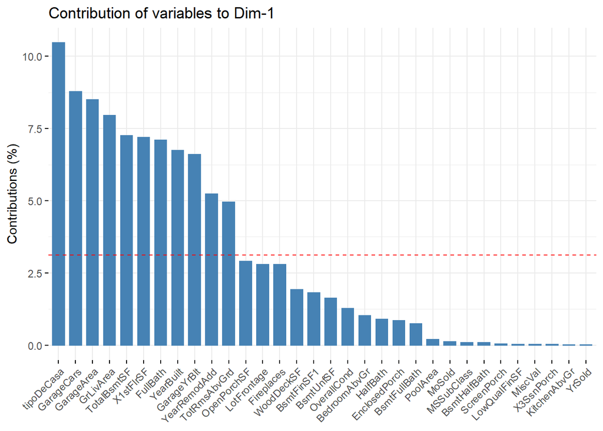

En la primera dimensión encontramos que 11 de las variables cuantitativas estan altamente representadas acá. Esas variables son tipoDeCasa, GarageCars, GarageArea, GrLivArea, TotalBsmtSF, X1stFlrSF, FullBath, YearBuilt, GarageYrBlt, YearRemodAdd y totRmsAbvGrd, estas variables nos dice sobre el tamaño de la casa y la calidad de la casa por lo que su nombre podía ser COndicionGeneral.

Proseguimos con las demás dimensiones.

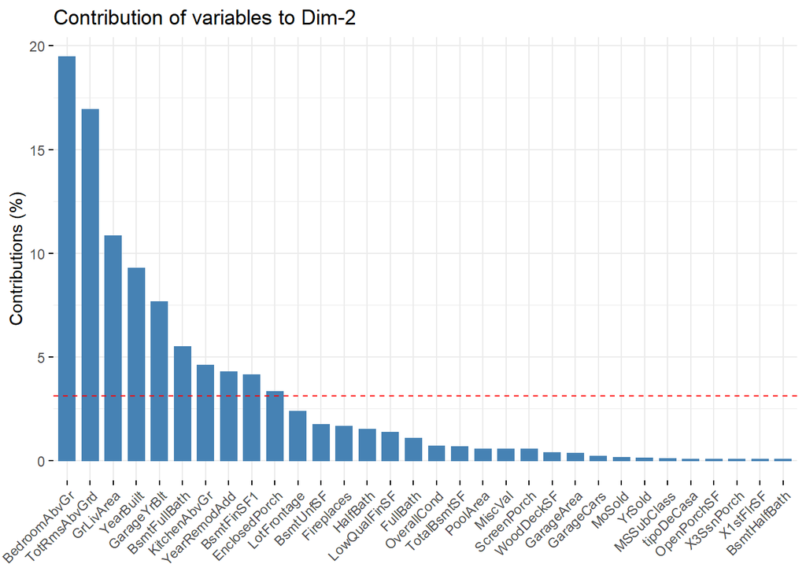

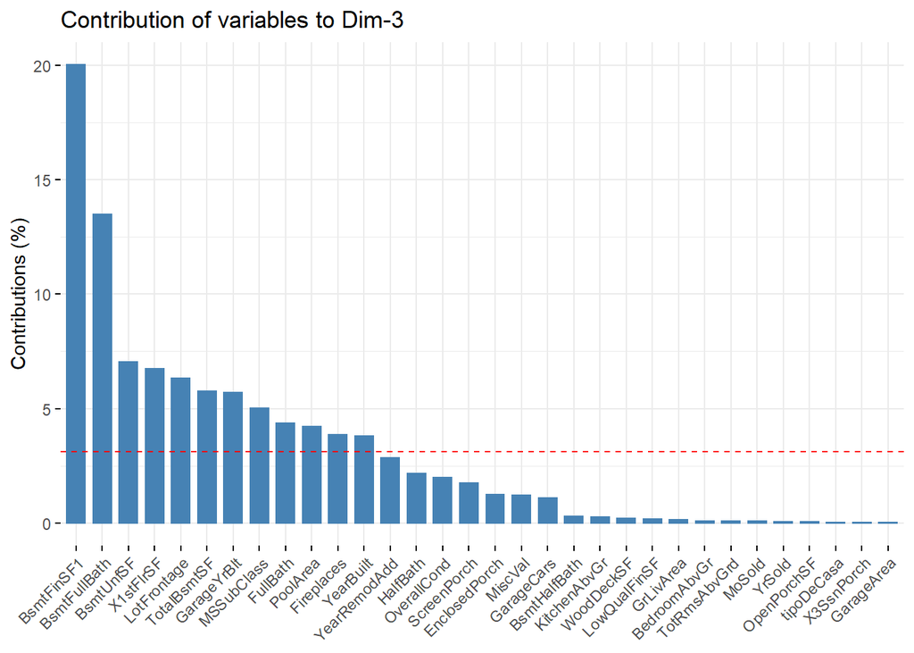

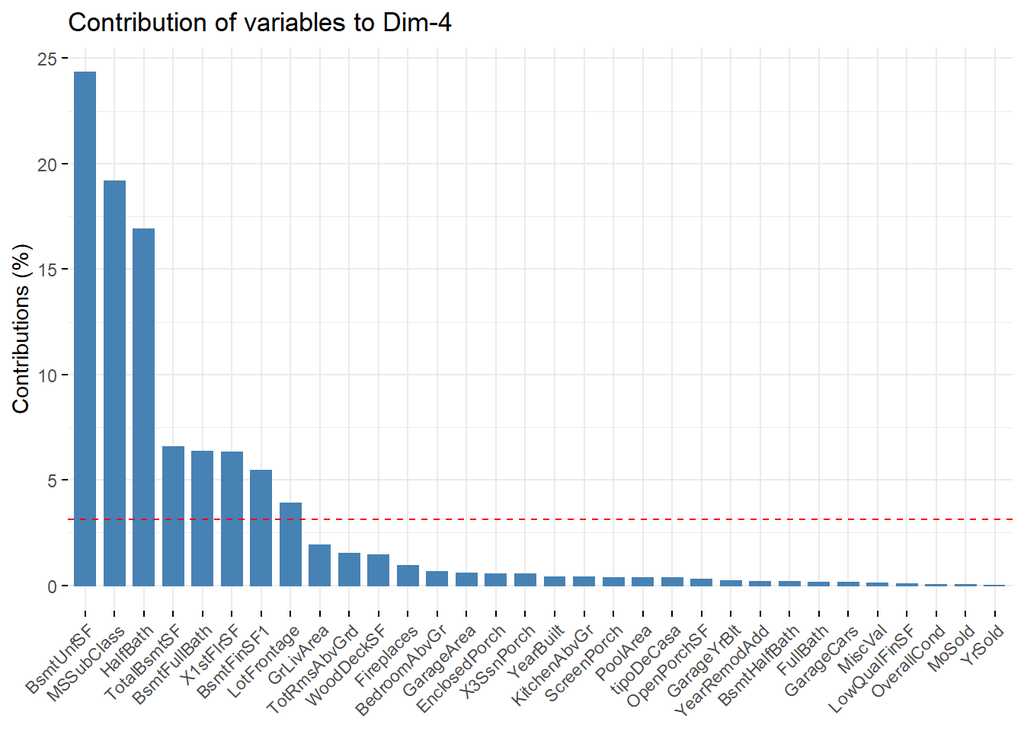

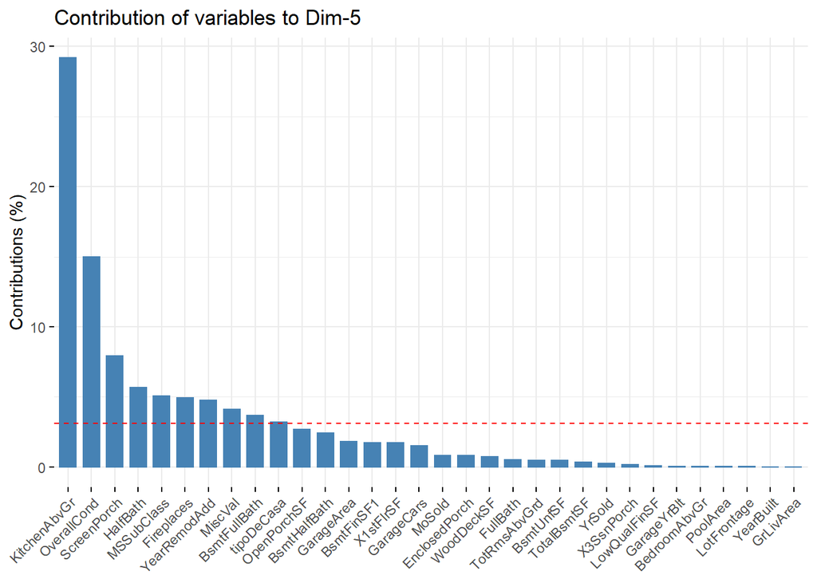